# walkthrough pupil preprocess

Yoni

2022-11-22

This is a walk-trough of pupil preprocessing (pp’ing) done for SOAL agency task.

It builds strongly on Paris’ pipeline & the Gazer package.

Highly recommended to first read the [GAZER paper] (https://link.springer.com/article/10.3758/s13428-020-01374-8) & do their [vignette] (https://github.com/dmirman/gazer/blob/master/vignettes/Pupil-vignette.Rmd)

```r
# knitr::opts_chunk$set(echo = FALSE)
knitr::opts_chunk$set(warning = FALSE, message = FALSE)
```

```r
library(rstudioapi)
library(hms)
library(Rmisc)
library(lubridate)
library(vroom)
library(ggpubr)
library(gazer)
library(tidyverse)
```

```r
## if there is an error here check that you have all files and they are located in the place denoted by script below

#parameters
source("parameters_for_pupil_pp_walkthrough.R")

#functions for pp' SoA task
source("functions_for_pp_SoA.R")

# custom functions for pupil PP
source("functions_for_pupil_pp.R")

#functions for pp'ing of eye movements and tracker data
source('functions4EM_analysis.R')
```

#loading files

Here we interactively select a single folder that contains (subfolders included) the entire SoA data (i.e., a single Answer, Trials, & tracker files)

As a sidenote, this is only for the walkthrough. In the pp’ing pipeline a script is run on a vector of subjects numbers that you define

```r
#fnames_df is tibble with pathes for all three files & subject name
fnames_df<-get_fnames_by_gui(sub_folder_suffix) #  this function is compatible also with macs
```

```r
# trial csv
trial_df<-read_csv(fnames_df$trial_fname,show_col_types = FALSE)

#answers
ans_df<-read_csv(fnames_df$ans_fname,show_col_types = FALSE)

#trkr
sub_trkr_output<- vroom(fnames_df$trkr_fname,show_col_types = FALSE)
```

# Processing behavioral SoA data

```r
#merge Trial & answer files to single df
behav_data_df<-merge_trial_ans_SoA(trial_df,ans_df,sub_name = fnames_df$sub_name)

#remove trials with non-positive index
behav_data_df<-behav_data_df%>%
  dplyr::filter(TrialNumber>0)
```

Preprocess the tracker file

```r
#remove calibration trial (trials with non-positive value)
trkr_df<-sub_trkr_output%>%
  dplyr::filter(TrialNumber>0)

#remove duplicate rows in trkr csv
trkr_df<-trkr_df%>%
  dplyr::group_by(TrialNumber)%>%
  distinct(FrameNumber,.keep_all=TRUE)

#change coding of pupil values from -1 to NA (this is necessary for GAZER package)
trkr_df<-trkr_df%>%
  mutate(left.pupil_diameter_mm=ifelse(left.pupil_diameter_mm == -1,NA,left.pupil_diameter_mm),
         right.pupil_diameter_mm=ifelse(right.pupil_diameter_mm == -1,NA,right.pupil_diameter_mm))


##converting tms to hms resolution (done via the function "convert_ts_to_hms")
trkr_df<-trkr_df%>%
  dplyr::rowwise()%>%
  dplyr::mutate(TimeStamp=convert_ts_to_hms(TimeStamp))

#add column with relative time in ms from start of first trial (i.e. experiment (exp))
trkr_df<-trkr_df%>%
  dplyr::ungroup()%>%
  dplyr::mutate(rel_time_exp=as.numeric(TimeStamp-first(TimeStamp))*1000)


#add column with relative time in ms from start of the trial. This is the time we use for the GAZER library
trkr_df<-trkr_df%>%
  dplyr::group_by(TrialNumber)%>%
  dplyr::mutate(rel_time_trial=as.numeric(TimeStamp-first(TimeStamp))*1000)


##adding EVEMT MESSAGES (in GAZER this allows for cutting and alighnment of trials & baseline correction based on specfic events)

#(TO DO ADD MESSAGES WHEN SUBJECT MOVED HAND etc. )
#PRBLY should also change the format of the function to allow additional add ons

#adding message when trial started & when Question was presented
trkr_df<-trkr_df%>%
  dplyr::group_by(TrialNumber)%>%
  mutate(lg_ss= lag(SecondarySceneName), lg_s=lag(SceneName),
         message=if_else(( SceneName=="Room"& SecondarySceneName =="NoBlockView" & lg_ss=="BlockView"),"start_room", #room start
                         if_else((SceneName=="Question" & lg_s=="Room"),"start_question","NA" ) #question start
         )
  )%>%
  dplyr::select(-c(lg_s,lg_ss))
```

# preliminary visulalizations of the pupil data and experiment

1. visualize experiment time course

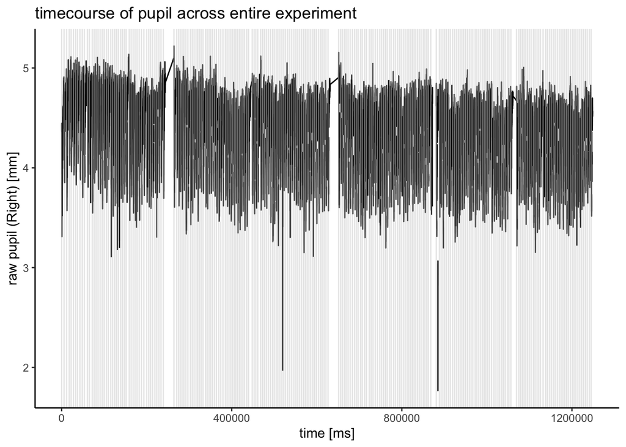

timecorse of pupil across entire experiment (grey lines=start of room)

```r
#plot
vlines<-trkr_df$rel_time_exp[which(trkr_df$message=="start_room")]

(
  ggplot(data = trkr_df,aes(x=rel_time_exp,y=right.pupil_diameter_mm))+
    geom_path(stat="identity")+
    geom_vline(xintercept = vlines, color="lightgrey", alpha=.5 )+
    ylab("raw pupil (Right) [mm]")+
    xlab("time [ms]")+
    theme_classic()+
    ggtitle("timecourse of pupil across entire experiment")
)
```

```r
### prep data

#getting mean across trials
mean_pup_per_trial_df<-trkr_df%>%
  dplyr::filter(rel_time_trial<end_time_zero)%>%
  dplyr::filter(!is.na(right.pupil_diameter_mm))%>%
  dplyr::group_by(TrialNumber)%>%
  dplyr::mutate(bin=findInterval(rel_time_trial,bin_vec))%>%
  dplyr::group_by(bin,TrialNumber)%>%
  dplyr::summarise(right.pupil_diameter_mm=mean(right.pupil_diameter_mm,na.rm=TRUE))%>%
  dplyr::group_by(bin)%>%
  dplyr::summarise(m_pup=CI(right.pupil_diameter_mm)[2],
                   hi_pup=CI(right.pupil_diameter_mm)[1],
                   lo_pup=CI(right.pupil_diameter_mm)[3])


#getting per trial
pup_per_trial_df<-trkr_df%>%
  dplyr::filter(rel_time_trial<end_time_zero)%>%
  dplyr::filter(!is.na(right.pupil_diameter_mm))%>%
  dplyr::group_by(TrialNumber)%>%
  dplyr::mutate(bin=findInterval(rel_time_trial,bin_vec))%>%
  dplyr::group_by(TrialNumber,bin)%>%
  dplyr::summarise(m_pup=CI(right.pupil_diameter_mm)[2])
```

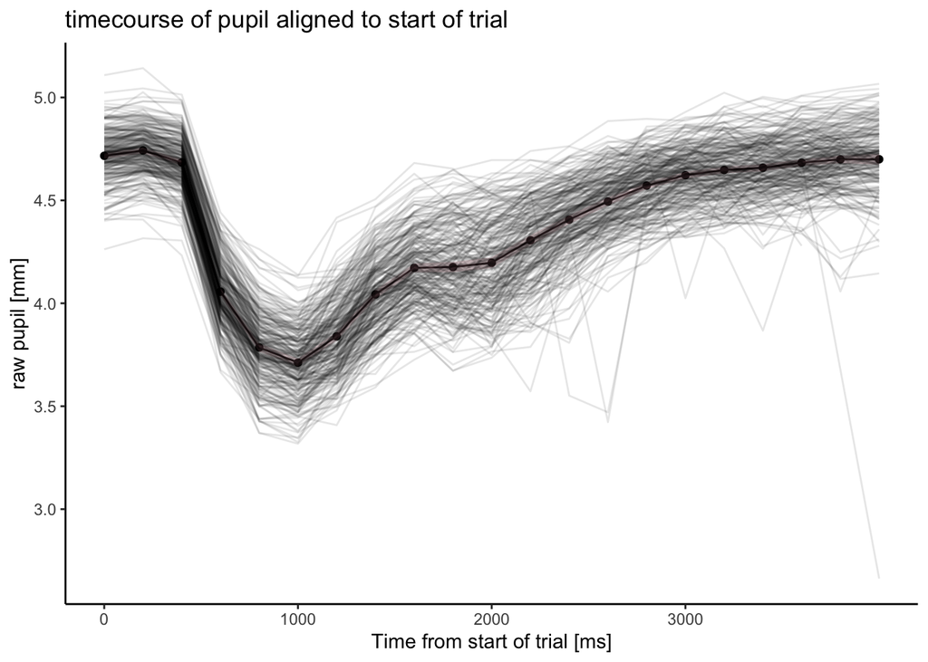

```r
###TO DO FIX ALIGNMENT TO BE START OF ROOM
#define values for plotting labels on x axis
tick_ind<-seq(from=1, to=n_bins, by=5) #define the labels you want to see
tick_labels<-as.character((tick_ind-1)*bin_dur_ms)


(
  ggplot(data=mean_pup_per_trial_df,aes(x=bin,y=m_pup))+
    geom_line()+
    geom_point()+
    geom_ribbon(aes(ymin=lo_pup ,ymax=hi_pup),alpha=.3,fill="pink")+
    geom_line(data=pup_per_trial_df,aes(x=bin,y=m_pup,group=TrialNumber),alpha=.1)+ #plot individual trials
    scale_x_continuous(name="Time from start of trial [ms]", labels = tick_labels,breaks = tick_ind)+
    ylab("raw pupil [mm]")+
    theme_classic()+
    ggtitle("timecourse of pupil aligned to start of trial")
)
```

TO DO! understand why CI is so small despite visible variability

2. correlation between pupil diameter in right & left eye

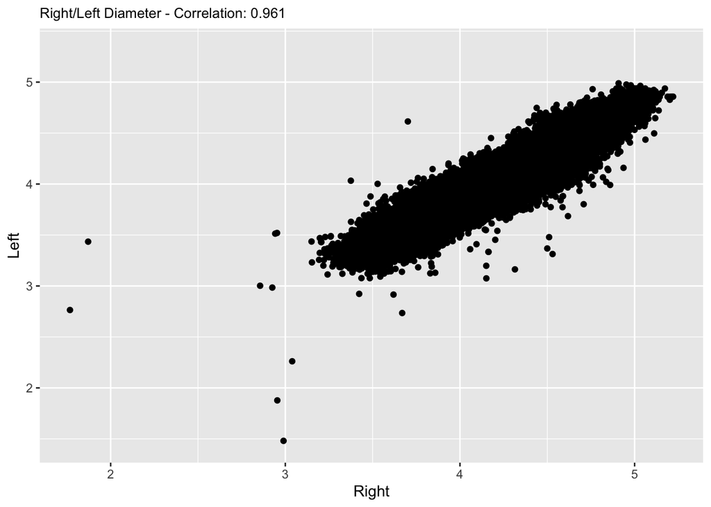

```r
(
  ggplot(data=trkr_df,aes(x=right.pupil_diameter_mm,y=left.pupil_diameter_mm))+
    geom_point()+
    ggtitle(sprintf("Right/Left Diameter - Correlation: %.3f",cor(trkr_df$right.pupil_diameter_mm,trkr_df$left.pupil_diameter_mm,use="complete.obs")))+
    labs(x="Right",y="Left")+
    theme(plot.title = element_text(size = 10))
)
```

3. correlation between eye gaze location (x,y,z) & pupil diameter

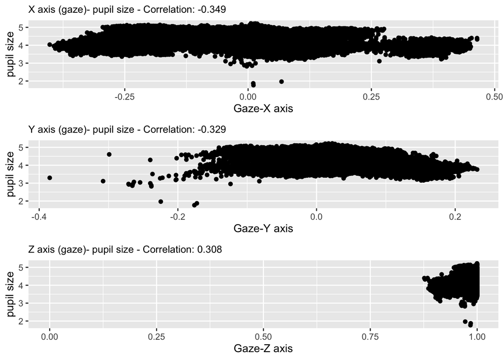

```r
plot_cor_pup_x <- ggplot(data=trkr_df,aes(x=right.gaze_direction_normalized.x,right.pupil_diameter_mm))+
  geom_point()+
  ggtitle(sprintf("X axis (gaze)- pupil size - Correlation: %.3f",cor(trkr_df$right.gaze_direction_normalized.x, trkr_df$right.pupil_diameter_mm,use="complete.obs")))+
  labs(x="Gaze-X axis",y="pupil size")+
  theme(plot.title = element_text(size = 10))

plot_cor_pup_y <- ggplot(data=trkr_df,aes(x=right.gaze_direction_normalized.y,right.pupil_diameter_mm))+
  geom_point()+
  ggtitle(sprintf("Y axis (gaze)- pupil size - Correlation: %.3f",cor(trkr_df$right.gaze_direction_normalized.y, trkr_df$right.pupil_diameter_mm,use="complete.obs")))+
  labs(x="Gaze-Y axis",y="pupil size")+
  theme(plot.title = element_text(size = 10))

plot_cor_pup_z <- ggplot(data=trkr_df,aes(x=right.gaze_direction_normalized.z,right.pupil_diameter_mm))+
  geom_point()+
  ggtitle(sprintf("Z axis (gaze)- pupil size - Correlation: %.3f",cor(trkr_df$right.gaze_direction_normalized.z, trkr_df$right.pupil_diameter_mm,use="complete.obs")))+
  labs(x="Gaze-Z axis",y="pupil size")+
  theme(plot.title = element_text(size = 10))

ggarrange(plot_cor_pup_x,plot_cor_pup_y,plot_cor_pup_z,ncol=1,nrow=3)
```

This is in line with literature that estimated pupil size varies according to gaze location because infrared sensor isn’t acuurate in periphery of screen. We need to account for this with different butterfly locations

4. histogram of all pupil values

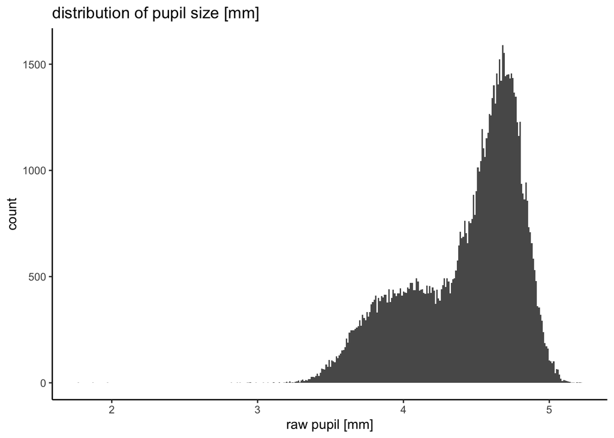

```r
(
  ggplot(data=trkr_df, aes(x=right.pupil_diameter_mm))+
    geom_histogram(binwidth = .01)+
    xlab("raw pupil [mm]")+
    theme_classic()+
    ggtitle("distribution of pupil size [mm]")
)
```

# Preprocessing of pupil

Great so now that we did some initial visualizations of the raw pupil data. Let’s start the preprocessing (pp) pipeline.

This is based on the GAZER package & Paris’ work

1. merge pupil with behav data

```r
## 1. merge with behavioral data & reordering columns (this will be called df.eye)
df.eye.raw<- left_join(trkr_df%>%
                         dplyr::select(TrialNumber,TimeStamp,rel_time_exp,rel_time_trial, right.pupil_diameter_mm,right.eye_openness,message,SceneName,SecondarySceneName),
                       behav_data_df%>%
                         dplyr::select(TrialNumber,delay,IsCong,is_acc,Conf,RT_IsCong,SDT_cat)
                       , by=c("TrialNumber"))%>%
  relocate(TrialNumber,delay,IsCong,is_acc,Conf,RT_IsCong)%>%
  dplyr::relocate(c("TimeStamp","rel_time_exp","SceneName","SecondarySceneName"),.after = last_col())%>%
  #rename columns according to GAZER requirments
  dplyr::rename(trial=TrialNumber, time=rel_time_trial,pupil=right.pupil_diameter_mm) %>%
  dplyr::mutate(subject=fnames_df$sub_name)

df.eye.raw
```

```
## # A tibble: 105,993 × 16
## # Groups:   trial [256]
##    trial delay IsCong is_acc  Conf RT_IsCong  time pupil right.eye_openness
##    <dbl> <dbl>  <dbl>  <dbl> <dbl>     <dbl> <dbl> <dbl>              <dbl>
##  1     1     0      1      1     6     0.978   0    4.43                  1
##  2     1     0      1      1     6     0.978  38.0  4.38                  1
##  3     1     0      1      1     6     0.978  47.0  4.39                  1
##  4     1     0      1      1     6     0.978  56.0  4.40                  1
##  5     1     0      1      1     6     0.978  64.0  4.43                  1
##  6     1     0      1      1     6     0.978  72.0  4.44                  1
##  7     1     0      1      1     6     0.978  80.0  4.41                  1
##  8     1     0      1      1     6     0.978  91.0  4.40                  1
##  9     1     0      1      1     6     0.978 102.   4.38                  1
## 10     1     0      1      1     6     0.978 113.   4.40                  1
## # … with 105,983 more rows, and 7 more variables: message <chr>, SDT_cat <chr>,
## #   TimeStamp <time>, rel_time_exp <dbl>, SceneName <chr>,
## #   SecondarySceneName <chr>, subject <chr>
```

```r
# ### TO DO- INTERPOLATE DATA TO A SET 11 HZ rate
#
# bin.length=30
#
# downsample <- df.eye.raw %>%
#     dplyr::mutate(timebins = round(time/bin.length)*bin.length)
#
#  downsample2 <- downsample %>%
#       dplyr::group_by(trial,timebins) %>%
#       dplyr::summarize(pup2=mean(pupil)) %>%
#       dplyr::ungroup()
#
# downsample = TRUE
# if (downsample){
#
#   df.raw2<- df.eye.raw %>% downsample_pupil(bin.length=30 )
# }
```

2. extending deblinking

we also remove the samples right next to the blink, because there is a rapid change in size due to the start/end of the blink

This explains the low values in the histogram above

```r
### Extending Debliniking #####
df.eye.pup_extended<- df.eye.raw %>%
  dplyr::mutate(extendpupil=extend_blinks(pupil,fillback = deblink_fill_back_val,fillforward = deblink_fill_forward_val,hz=init_sample_rate))%>%
  relocate(c("extendpupil"),.after=pupil)


### sanity check that we have more nans per trial
n_nan<-df.eye.pup_extended%>%
  dplyr::group_by(trial)%>%
  dplyr::summarise(n_nan_extend=length(which(is.na(extendpupil))),
                   n_nan_raw=length(which(is.na(pupil))),
                   tot_n=length(pupil),
                   p_nan_extend=n_nan_extend/tot_n,
                   p_nan_raw=n_nan_raw/tot_n)%>%
  dplyr::mutate(diff_nan_p=p_nan_extend-p_nan_raw)

##TO DO ADD VISUALIZATION of % NANs, maybe 100 ms is too much???

#add vis of deblinking? maybe first 10 trials
```

3. Smoothing ( moving average) & interpolating (i.e. linear) data

(via “smooth_interpolate_pupil” function)

Linear interpolation is generally considered good enough for pupil data

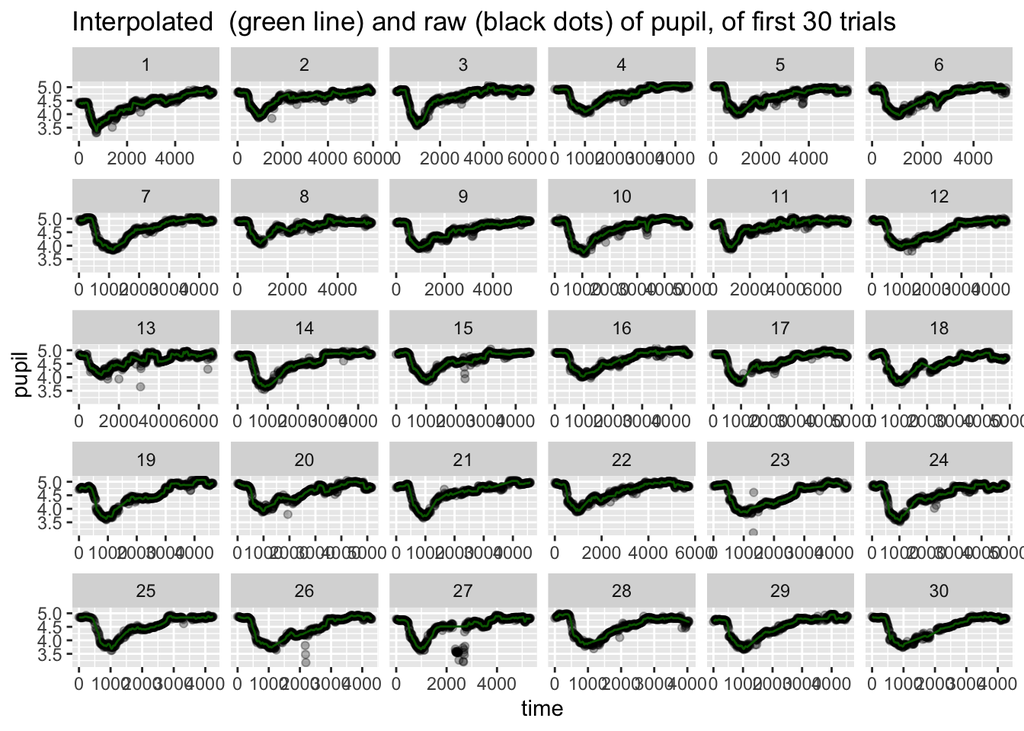

```r
##### smoothing & interpolating ######
# see GAZER documentation for documentation of input arguments.
# Linear interpolation is
df.eye.smooth_interp <- smooth_interpolate_pupil(df.eye.pup_extended,
                                                 pupil="pupil",
                                                 extendpupil="extendpupil",
                                                 extendblinks=TRUE,
                                                 step.first="interp",
                                                 filter="moving",
                                                 maxgap=5, #  is1 second
                                                 type="linear",
                                                 hz=init_sample_rate,
                                                 n=5)%>%
  dplyr::relocate(c("interp","pup_interp"),.after=extendpupil)%>% #relocate col for convenience
  dplyr::select(-interp) #interp is the same as extendedpupil


#### visualize

#plotting per trial (first 30 trials so that you can see something )
(
  ggplot(data=df.eye.smooth_interp%>%dplyr::filter(trial<31),aes(x=time,y=pupil))+
    geom_point(alpha=.3)+
    geom_line(aes(x=time, y=pup_interp), colour="darkgreen") + #adding the interpolated line
    facet_wrap(~trial,scales = "free_x")+
    ggtitle("Interpolated  (green line) and raw (black dots) of pupil, of first 30 trials")
)
```

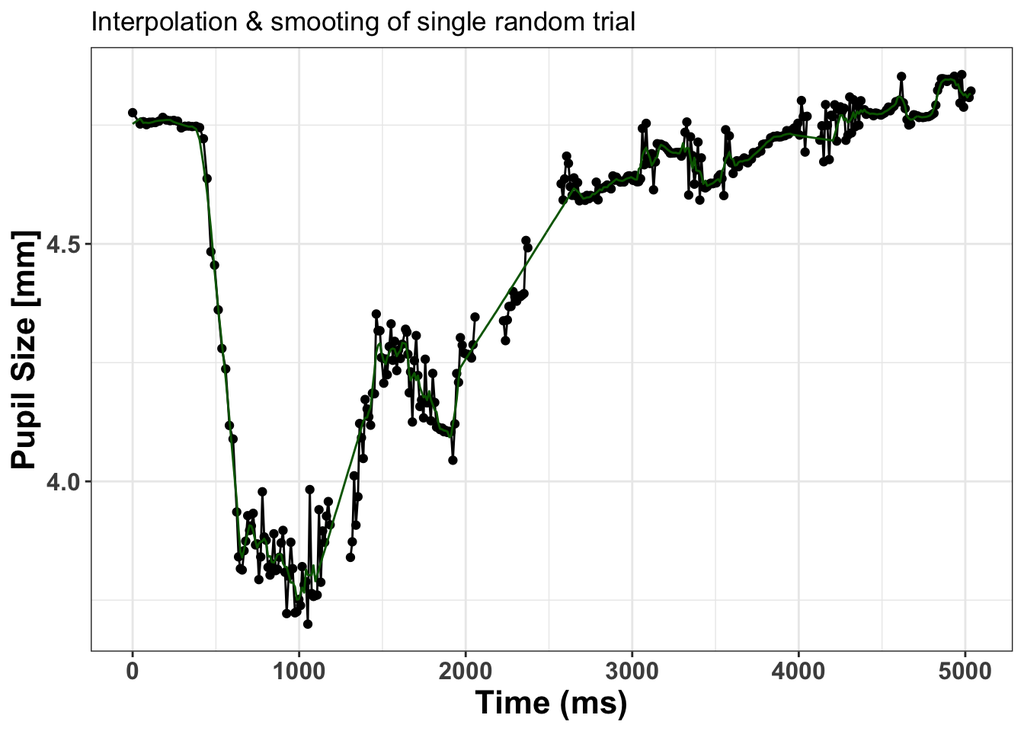

```r
#viualize interpolation of random trial
(
  ggplot(df.eye.smooth_interp%>%
           dplyr::filter(trial==45), aes(x= time, y= pupil))+
    geom_point()+
    geom_line(colour="black") +
    geom_line(aes(x=time, y=pup_interp), colour="darkgreen") +
    xlab("Time (ms)") +
    ylab("Pupil Size [mm]") +
    ggtitle("Interpolation & smooting of single random trial")+
    theme_bw() +
    theme(axis.title.y=element_text(size = 16, face="bold"),
          axis.title.x = element_text(size=16, face="bold"),
          axis.text.x=element_text(size = 12, face="bold"),
          axis.text.y=element_text(size=12, face="bold"))
)
```

4. Baseline correction

IN my opinion this is tricky! we see that in the start of the trial there is a steep decrease (prbly due to increase in light) that lasts for first second

from Paris: “Pupil sizes varies a lot between subjects and trials. Thats why usually, you select a period to baseline correct. Substraction is enough, as pupil effects are quite linear. For this, you need a column named”message”, that provides the stamp of the period, before which you think your eye was in baseline. Choice of baseline is usually irrelevant, as long as it is constant in all subjects/trials.”

Maybe use a baseline that is 100 msec prior to hand movement?

```r
df.eye.baseline<-baseline_correction_pupil_msg(datafile=df.eye.smooth_interp,
                                               pupil_colname='pup_interp',
                                               baseline_dur=100,
                                               event="start_room",
                                               baseline_method = "sub")%>%
  dplyr::relocate("baselinecorrectedp",.after = pupil)%>%
  dplyr::relocate("baseline",.after=last_col())

head(df.eye.baseline)
```

```
## # A tibble: 6 × 20
##   subject trial delay IsCong is_acc  Conf RT_IsCong  time pupil baselinecorrect…
##   <chr>   <dbl> <dbl>  <dbl>  <dbl> <dbl>     <dbl> <dbl> <dbl>            <dbl>
## 1 Sub_15      1     0      1      1     6     0.978   0    4.43        -0.00741
## 2 Sub_15      1     0      1      1     6     0.978  38.0  4.38        -0.00750
## 3 Sub_15      1     0      1      1     6     0.978  47.0  4.39        -0.00230
## 4 Sub_15      1     0      1      1     6     0.978  56.0  4.40         0.000272
## 5 Sub_15      1     0      1      1     6     0.978  64.0  4.43         0.00737
## 6 Sub_15      1     0      1      1     6     0.978  72.0  4.44         0.00884
## # … with 10 more variables: extendpupil <dbl>, pup_interp <dbl>,
## #   right.eye_openness <dbl>, message <chr>, SDT_cat <chr>, TimeStamp <time>,
## #   rel_time_exp <dbl>, SceneName <chr>, SecondarySceneName <chr>,
## #   baseline <dbl>
```

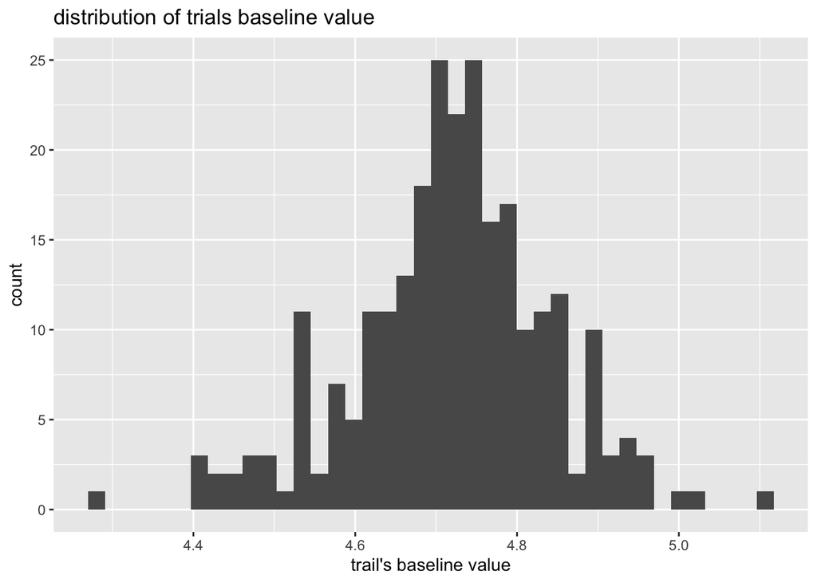

```r
## visualize distribution of pupil baseline
##get each trial's baseline
baseline_vals<-df.eye.baseline%>%
  dplyr::group_by(trial)%>%
  dplyr::summarize(baseline=first(baseline)) #using first beacase the baseline val is constant througout the trial

# visualize
(
  ggplot(data=baseline_vals,aes(x=baseline))+
    geom_histogram(bins=40)+
    xlab("trail's baseline value")+
    ggtitle("distribution of trials baseline value")
)
```

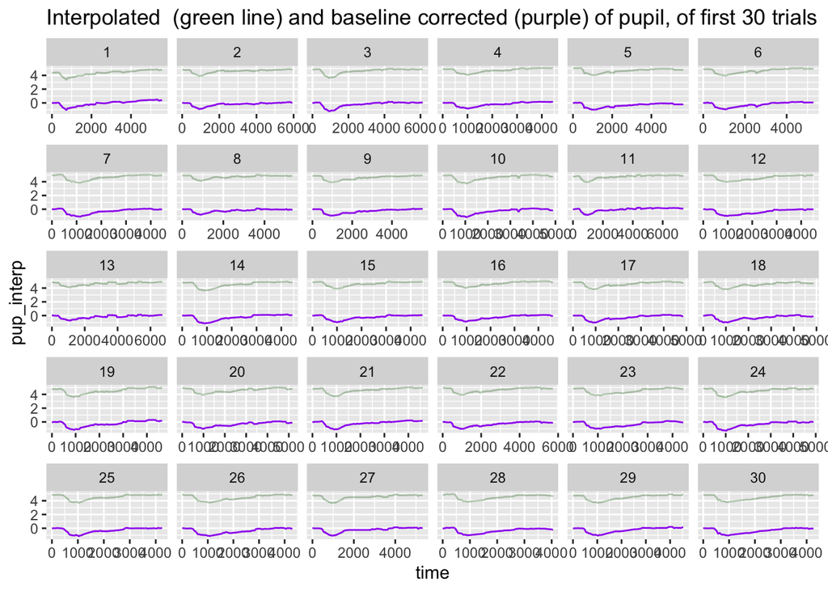

```r
## visualizing subset of trials

(
  ggplot(data=df.eye.baseline%>%dplyr::filter(trial<31),aes(x=time,y=pup_interp))+
    geom_line( colour="darkgreen",alpha=.3) + #adding the interpolated line
    geom_line(aes(x=time, y=baselinecorrectedp),color="purple")+
    facet_wrap(~trial,scales = "free_x")+
    ggtitle("Interpolated  (green line) and baseline corrected (purple) of pupil, of first 30 trials")
)
```

5. artifact rejection

Based on Mathot- it is reccomended using visual inspection of distribution of interpolated pupil values to determine cut-off. this is opposed to using predetermined threshods

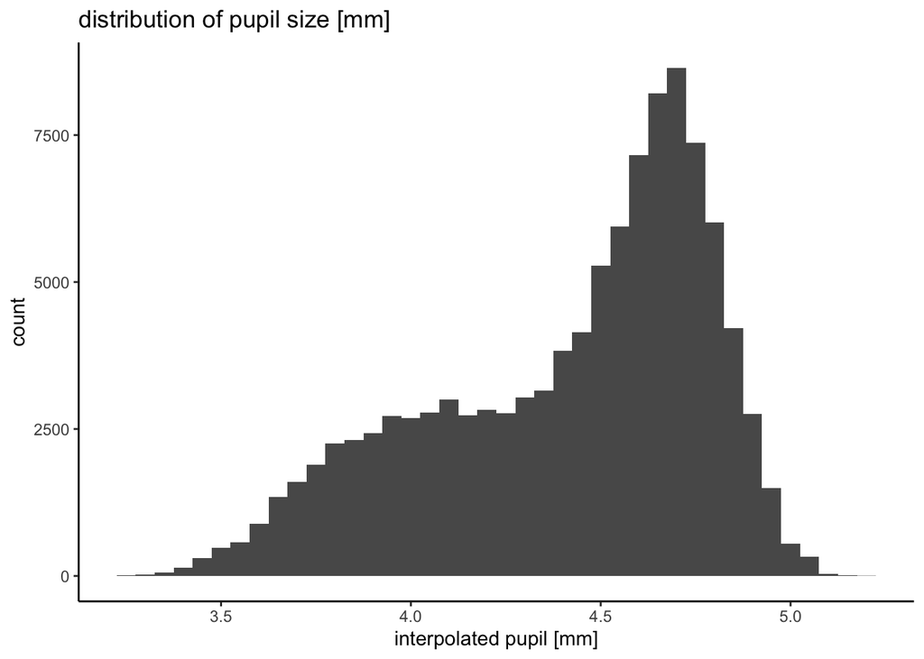

```r
#visualize distribution
(
  ggplot(data=df.eye.baseline,aes(x=pup_interp))+
    geom_histogram(binwidth =.05)+
    xlab("interpolated pupil [mm]")+
    theme_classic()+
    ggtitle("distribution of pupil size [mm]")
)
```

IMO no clear outliers. In general this shouldn’t effect data much

6. Scaling of data- convert to Z-score this allows for comparison between subjects This is done per subject & per trial

```r
df.eye.pupilz<-df.eye.baseline%>%
  group_by(subject, trial) %>%
  mutate(pupilz=scale_this(baselinecorrectedp))%>% #getting z score. Using custom function scale_this. See function for details
  dplyr::relocate("pupilz",.after=pupil)
```

7.filter trials out if they have too many missing samples

```r
df.eye.removemiss<-count_missing_pupil(df.eye.pupilz,missingthresh = missing_thresh_per_trial)
```

8. Median Absolute Deviation (MAD) removal-

Based on Kret-Sjak-Shie (2018) we filter out trials in which pupil dilation occurs too quickly. First,pupil dilation speed is calculated, then a threshold is set by taking the MAD and multiplying it by a constant. Timepoints in which the pupil speed exceeds the treshold are filtered out.

```r
df.eye.mad<-df.eye.removemiss%>%
  dplyr::group_by(subject,trial)%>%
  dplyr::mutate(speed=speed_pupil(pup_interp,time = time))%>% #calculated speed of pupil dilation (currently doing interpolated value) NEED to read article and see if this can be done on z-score of pupil
  dplyr::mutate(MAD=calc_mad(speed,n=16))%>% #n=16 is the constant used to multiply. for now we'll stick to it
  filter(speed < MAD)
```

9. Event Time Alignment

We are almost done!!

Now we’ll align the trials according to our event of interest

```r
df.eye.align<-df.eye.mad%>%
  dplyr::group_by(subject,trial)%>%
  dplyr::mutate(time_zero=onset_pupil(time,marker=message,event=c("start_room")))%>% #time_zero is aligned according to start of room
  dplyr::ungroup()%>%
  dplyr::filter(time_zero>= start_time_zero & time_zero <=end_time_zero)
```

10. downsampling

```r
##Gazer's downasample isn't working.
#Instead using findInterval function
## TO DO!! merge align with the initial visualization


df.eye.downsmpl<-df.eye.align%>%
  dplyr::mutate(bin=findInterval(time_zero,bin_vec))%>% #maybe subtract from bin so that before baseline is negative?
  dplyr::group_by(subject,trial,bin)%>%
  dplyr::mutate(pupil_ds=mean(baselinecorrectedp))%>% #maybe change this to summarize?
  dplyr::group_by(subject,trial,bin)%>%
  dplyr::filter(row_number()==1)

#This is it!!! renaming the downsampled df as the final df
df.pup.processed<-df.eye.downsmpl%>%
  dplyr::select(c(subject,trial,pupil_ds,bin,delay:RT_IsCong))%>% #selecting relevant columns
  dplyr::mutate(bin=(bin-2)*bin_dur_ms)%>%
  dplyr::mutate(is_altered=if_else(delay==0,"unaltered","altered"))
```

WALLA we have finished preprocessing !!

#Visualizing some results of SoA (just cause they are nice)

```r
##summarizing
df.pup.per_mag<-df.pup.processed%>%
  dplyr::group_by(subject,bin,delay)%>%
  dplyr::summarize(pup_proc=mean(pupil_ds),hi_pup=CI(pupil_ds)[1],lo_pup=CI(pupil_ds)[3])
```

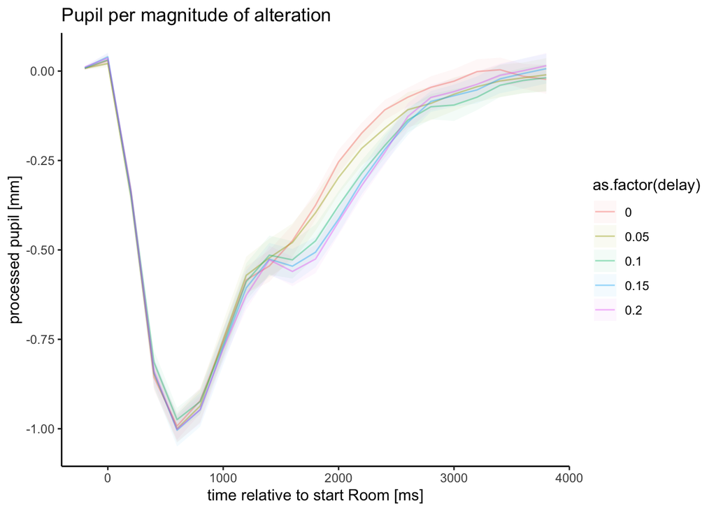

```r
(
  ggplot(df.pup.per_mag%>%filter(bin<36*bin_dur_ms),aes(x=bin, y=pup_proc, group=as.factor(delay), color=as.factor(delay)))+

    geom_ribbon(aes(ymin=lo_pup,ymax=hi_pup,fill=as.factor(delay)),alpha=.05,colour = NA)+
    geom_line(alpha=.4)+
    theme_classic()+
    ylab("processed pupil [mm]")+
    xlab("time relative to start Room [ms]")+
    ggtitle("Pupil per magnitude of alteration")
)
```

```r
df.pup.per_alter<-df.pup.processed%>%
  dplyr::group_by(subject,bin,is_altered)%>%
  dplyr::summarize(pup_proc=mean(pupil_ds),hi_pup=CI(pupil_ds)[1],lo_pup=CI(pupil_ds)[3])
```

Looks interesting.

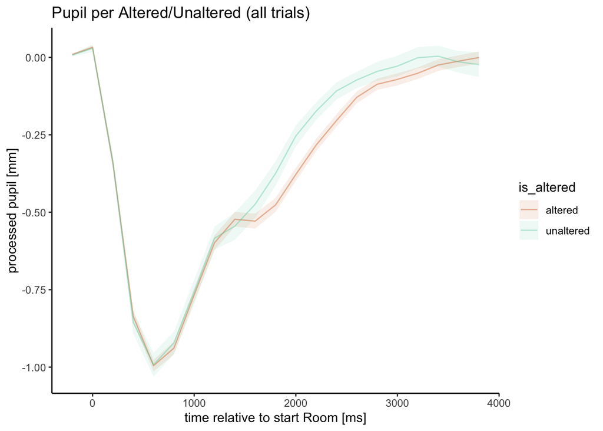

```r
c_vec<-c("chocolate3","aquamarine3")
(
  ggplot(df.pup.per_alter%>%filter(bin<36*bin_dur_ms),
         aes(x=bin, y=pup_proc, group=is_altered, color=is_altered))+

    geom_ribbon(aes(ymin=lo_pup,ymax=hi_pup,fill=is_altered),alpha=.1,colour = NA)+
    geom_line(alpha=.4)+
    scale_fill_manual(values=c_vec)+
    scale_color_manual(values=c_vec)+
    theme_classic()+
    ylab("processed pupil [mm]")+
    xlab("time relative to start Room [ms]")+
    ggtitle("Pupil per Altered/Unaltered (all trials)")
)
```